# Taller 9 (IMSE1017)

Visualización de mapas con {tmap}

Autor/a

Afiliación

Dr. Francisco Zambrano

Escuela de Ingeniería en Medio Ambiente, Universidad Mayor

Fecha de publicación

11 de noviembre de 2024

## 1 Descripción

En la primera parte del curso se familiarizó con R [@R2023], las principales estructuras de datos, como realizar indexación, conoció algunas funciones y pudo realizar algunos gráficos básicos; utilizando R base. Ahora, en el curso hemos empezado a trabajar en R con datos geoespaciales de tipo vectoriales y raster. Para manejar datos vectoriales utilizamos `{sf}` y para datos de tipo raster `{terra}`. Para visualizar mapas podemos utilizar las funciones base de `R`, pero también la librería `{tmap}`.

## 2 Objetivo del taller

Visualización de mapas estáticos y dinámicos con `{tmap}`

## 3 Paquetes R

Hasta el momento hemos trabajado con los paquetes que vienen inculidos en R base. Ahora empezaremos a trabajar con paquetes adicionales que no vienen instalados por defecto en `R`, por lo que deberá instalarlos. Los paquetes con los que trabajaremos este taller so `{terra}`, `{sf}` y `{tmap}` los que nos permitirán trabajar con datos raster, vectoriales y crear mapas. Además va a utilizar un paquete adicional el cual permite descargar a `R` datos raster de elevación `{elevatr}`.

Para instalar los paquetes debe realizar lo siguiente:

**Código**

```r
# instala los paquetes
install.packages(c('sf','terra','tmap','elevatr'))

# carga los paqutes en el entorno de R y permite utilizar
# las funciones adicionales que contienen

library(sf)
library(terra)
library(tmap)
```

## 4 Data

Trabajará con los datos vectoriales de la delimitación de `cuencas hidrográficas` y `estaciones meteorológicas`.

## 5 ¿Qué debe entregar?

Debeŕa utilizar RStudio para crear un script, el cual permitira generar los mapas indicados. Debe utilizar los comentarios (`#`) para hacer una descripción e incorporar cualquier información que ayude a entender lo realizado. A modo de ejemplo:

**Código**

```r
# Ejercicio 1:
# comentario explicando lo que se hace
{
  Aca va el script que resuelve el ejericio 1

}
```

Debe guardar el script con el nombre `taller9.R`. Los archivos los debe subir en el campus virtual en la sección `Evaluaciones -> Taller 9`

## 6 Fecha de entrega

Lunes 11 de noviembre hasta las 23:59am

## 7 Creación de modelo digital de elevación para una cuenca de Chile

1. Cargue los archivos vectoriales correspondientes a (20pts):
- `cuencas_chile`
- `estaciones_chile`

**Código**

```r
library(sf)
```

**Código**

```r
library(terra)
```

**Código**

```r
estaciones <- read_sf('../data/estaciones_chile/estaciones_chile.shp')
cuencas <- read_sf('../data/cuencas_Chile/Cuencas_BNA.shp')
```

2. Seleccione la cuenca del río Maipo y asígnela a un nuevo objeto en `R` (ej, cuenca_{nombre_cuenca}) (30pts).

**Código**

```r
cuenca_maipo <- cuencas[cuencas$NOM_CUEN == 'Rio Maipo',]
```

3. Seleccione las estaciones climáticas que se encuentran en la cuenca utilizada y asígnela a un nuevo objeto en `R` (ej, estaciones_{nombre_cuenca}) (40pts).

**Código**

```r
cuenca_maipo <- st_transform(cuenca_maipo,4326)

estas_maipo <- st_intersection(estaciones,cuenca_maipo)
```

**Código**

```r
library(elevatr)
```

**Código**

```r
dem <- get_elev_raster(cuenca_maipo,z = 9)
```

```
Mosaicing & Projecting
```

```
Note: Elevation units are in meters.
```

5. Haga una mascara del dem para la cuenca asignada, elimine los espacios en blanco (40pts).

**Código**

```r
dem_maipo <- trim(mask(dem,cuenca_maipo))
```

6. Cree un hillshade (mapa de sombras) del dem. Para esto debe crear un raster de aspecto (dirección) y slope (pendiente) a partir de el `dem`. Debe utilizar las funciones de `{terra}` `terrain` y `shade` (70pts).

**Código**

```r
dem_maipo <- rast(dem_maipo)
slope <- terrain(dem_maipo, v='slope',unit = 'radians')
aspect <- terrain(dem_maipo, v='aspect',unit = 'radians')
hill <- shade(slope, aspect)
```

7. Utilice `{tmap}` para crear la visualización del hillshade. Asigne el mapa creado al objeto `mapa` (50pts)

**Código**

```r
library(tmap)
```

**Código**

```r
tmap_mode('plot')
```

```
tmap mode set to plotting
```

**Código**

```
stars object downsampled to 1168 by 855 cells. See tm_shape manual (argument raster.downsample)
```

```
stars object downsampled to 1168 by 855 cells. See tm_shape manual (argument raster.downsample)
```

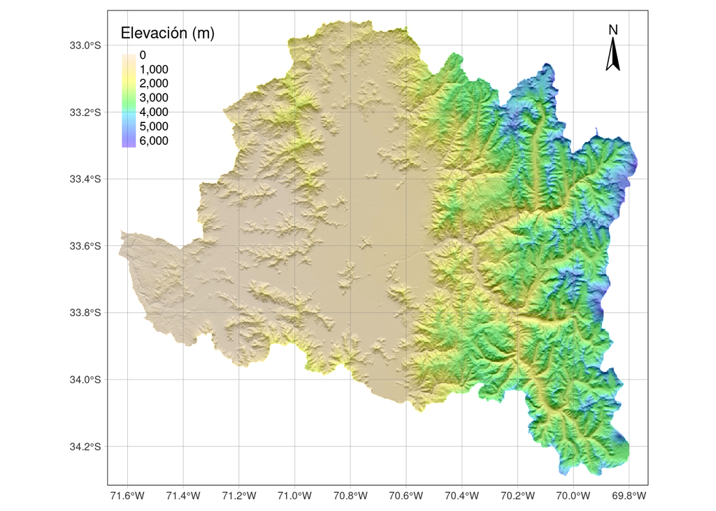

```r
mapa <- tm_shape(hill) +
  tm_raster(style = 'cont',palette = grey(0:100/100),legend.show = FALSE) +
  tm_shape(dem_maipo) +
  tm_raster(title= 'Elevación (m)', style ='cont',palette = rev(topo.colors(20)),alpha = .4) +
  tm_graticules(lwd = .4,alpha = .6) +
  tm_compass(position = c('right','top'))

mapa
```

## 8 Agregar límites de la cuenca y estaciones (80pts)

1. Cree un mapa de los bordes de la cuenca.
2. Agrege al mapa las estaciones que corresponden a la cuenca.
3. Una el mapa del punto anterior con el de los límites de la cuenca y las estaciones.
4. Transforme el mapa anterior en un mapa interactivo

**Código**

```r
mapa2 <- tm_shape(cuenca_maipo) +
  tm_borders() +
  tm_shape(estas_maipo,size=3) +
  tm_dots()

mapa <- mapa+mapa2
tmap_mode('view')
```

```
tmap mode set to interactive viewing
```

**Código**

```r
mapa
```

```
Compass not supported in view mode.
```

```
stars object downsampled to 1168 by 855 cells. See tm_shape manual (argument raster.downsample)
stars object downsampled to 1168 by 855 cells. See tm_shape manual (argument raster.downsample)
```

[interactive chart not shown]

## 9 Export mapas creados (40pts)

**Código**

```r
tmap_save(mapa,'../../img/mapa_hillshade.png')
tmap_save(mapa,'../../img/mapa_hillshade.html')
```